# Statistical Methods in Data Science and Laboratory II: Final Project

Valerio Antonini 1611556

# Introduction

The purpose of this project is to lead a bayesian analysis dealing with the growth of the height of a population of Loblolly pine trees.

```r
library(datasets)
library(R2jags)
library(ggplot2)
library(ggmcmc)
data("Loblolly")
```

# Data analysis

The Loblolly data frame has 84 rows and 3 columns of records of the growth of Loblolly pine trees. The three columns are:

- ‘height’: a numeric vector of tree heights (ft).
- ‘age’: a numeric vector of tree ages (yr).
- ‘Seed’: an ordered factor indicating the seed source for the tree. The ordering is according to increasing maximum height.

First of all i trasformed the original dataset into a new one. The ‘new’ dataset is composed by 6 columns (the different ages at which the height was recorded) and 14 rows: the height tree by tree at the different ages.

```r
loblolly.data <- list(x=c(3,5,10,15,20,25), x.bar=13, N=14, T = 6, Y=c(Loblolly$height))


Y<-matrix(loblolly.data$Y, nrow=loblolly.data$N, ncol=loblolly.data$T, byrow=TRUE)
Y
```

```
##       [,1]  [,2]  [,3]  [,4]  [,5]  [,6]
##  [1,] 4.51 10.89 28.72 41.74 52.70 60.92
##  [2,] 4.55 10.92 29.07 42.83 53.88 63.39
##  [3,] 4.79 11.37 30.21 44.40 55.82 64.10
##  [4,] 3.91  9.48 25.66 39.07 50.78 59.07
##  [5,] 4.81 11.20 28.66 41.66 53.31 63.05
##  [6,] 3.88  9.40 25.99 39.55 51.46 59.64
##  [7,] 4.32 10.43 27.16 40.85 51.33 60.07
##  [8,] 4.57 10.57 27.90 41.13 52.43 60.69
##  [9,] 3.77  9.03 25.45 38.98 49.76 60.28
## [10,] 4.33 10.79 28.97 42.44 53.17 61.62
## [11,] 4.38 10.48 27.93 40.20 50.06 58.49
## [12,] 4.12  9.92 26.54 37.82 48.43 56.81
## [13,] 3.93  9.34 26.08 37.79 48.31 56.43
## [14,] 3.46  9.05 25.85 39.15 49.12 59.49
```

```r
x<-loblolly.data$x
N<-loblolly.data$N
T<-loblolly.data$T
x_bar = loblolly.data$x.bar

cat('Recorded ages: ', x)
```

```
## Recorded ages:  3 5 10 15 20 25
```

```r
cat('Number of recorded ages: ', T)
```

```
## Number of recorded ages:  6
```

```r
cat('Number of trees: ', N)
```

```
## Number of trees:  14
```

```r
cat('Average height : ', mean(Y))
```

```
## Average height :  32.3644
```

Let’s see the behavior of each trees’ height to the various ages:

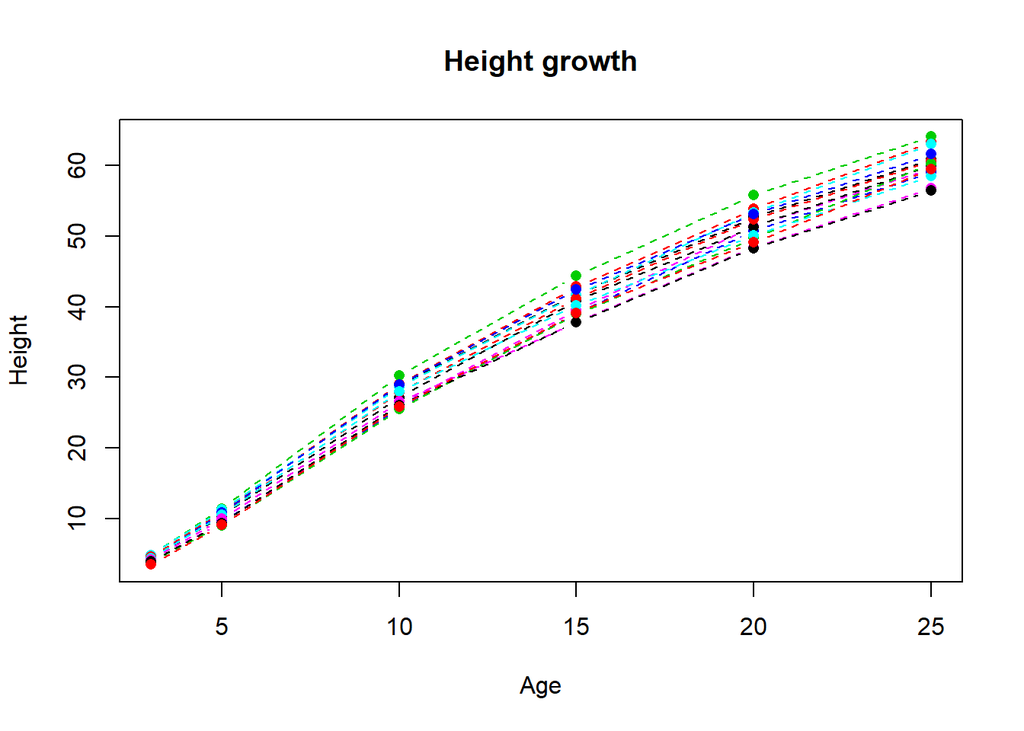

```r
matplot(loblolly.data$x,t(Y), type='b', pch=16, lty=2, xlab='Age', ylab='Height', main='Height growth')
```

Each trees’ height follows a linear growth. Due to similarity with the behavior of rats’ height study by Gelfand et al (1990), i decided to used rats example in Open Bugs for the building of the model.

It’s important to analyze the frequentist approach in order to get more info on the parameters and to evaluate the difference between the two process. The frequentist estimate of the parameters could help us to determine the init values for the jags model. The approach was conceived by getting a mathematical linear equation that relates the features and the response variable. This was done by linear regression

```r
array_intercept <- rep(NA,N)
array_slope <- rep(NA,N)
for(i in 1:N)
{
  linear_reg <- lm(Y[i,] ~ x)
  array_intercept[i] <- linear_reg$coefficients[[1]]
  array_slope[i] <- linear_reg$coefficients[[2]]
}

summary(linear_reg)
```

```
##
## Call:
## lm(formula = Y[i, ] ~ x)
##
## Residuals:
##        1        2        3        4        5        6
## -1.84459 -1.39768  2.54462  2.98692  0.09922 -2.38849
##
## Coefficients:
##             Estimate Std. Error t value Pr(>|t|)
## (Intercept)  -2.4100     2.0310  -1.187    0.301
## x             2.5715     0.1337  19.229 4.31e-05 ***
## ---
## Signif. codes:  0 '***' 0.001 '**' 0.01 '*' 0.05 '.' 0.1 ' ' 1
##
## Residual standard error: 2.572 on 4 degrees of freedom
## Multiple R-squared:  0.9893, Adjusted R-squared:  0.9866
## F-statistic: 369.8 on 1 and 4 DF,  p-value: 4.31e-05
```

```r
array_intercept
```

```
##  [1] -0.6601441 -1.1489820 -0.6964865 -2.0683153 -0.9813874 -2.1828559
##  [7] -1.1494324 -0.9741982 -2.6357658 -0.8783964 -0.4456126 -0.8810901
## [13] -1.2608559 -2.4100270
```

```r
array_slope
```

```
##  [1] 2.608216 2.711973 2.754730 2.568973 2.674081 2.602784 2.577649
##  [8] 2.604297 2.603649 2.648595 2.489919 2.422135 2.428784 2.571541
```

```r
mean_alpha_freq <- mean(array_intercept)
cat('The intercept mean for frequentist approach: ', round(mean_alpha_freq,2))
```

```
## The intercept mean for frequentist approach:  -1.31
```

```r
mean_beta_freq <- mean(array_slope)
cat('The slope mean for frequentist approach:: ', round(mean_beta_freq,2))
```

```
## The slope mean for frequentist approach::  2.59
```

# Model 1

The model is essentially a random effects linear growth curve:

$$Y_{ij}\sim Norm(\mu_{ij},\tau_c)$$
$$\mu_{ij}\sim\alpha_i+\beta_i(x_j-\bar{x})$$
$$\tau_c\sim Gamma(0.001,0.001)$$
$$\alpha_i\sim Norm(\alpha_c,\tau_{\alpha})$$
$$\beta_i\sim Norm(\beta_c,\tau_{\beta})$$
$$\alpha_c\sim Norm(0,10^{-6})$$
$$\beta_c\sim Norm(0,10^{-6})$$
$$\tau_{\alpha}\sim Gamma(0.001,0.001)$$
$$\tau_{\beta}\sim Gamma(0.001,0.001)$$

where $\tau$ represents the precision (1/variance) of a normal distribution. We standardise the $x_j$’s around their mean to reduce dependence between $\alpha_i$ and $\beta_i$ in their likelihood: in fact for the full balanced data, complete independence is achieved. (Note that, in general, prior independence does not force the posterior distributions to be independent). $\alpha_c\,,\beta_c\,,\tau_{\alpha}\,,\tau_{\beta}\,,\tau_c$ are “non-informative” priors.

```r
model <- function()  {
  for (i in 1:N) {
    for (j in 1:T) {
      Y[i,j]   ~ dnorm(mu[i,j],tau.c)
      mu[i,j] <- alpha[i] + beta[i]*(x[j]-x.bar);
    }

    alpha[i] ~ dnorm(alpha.c,tau.alpha);
    beta[i]  ~ dnorm(beta.c,tau.beta); }
    alpha.c   ~ dnorm(0,1.0E-6);
    beta.c    ~ dnorm(0,1.0E-6);
    tau.c     ~ dgamma(1.0E-3,1.0E-3);
    tau.alpha ~ dgamma(1.0E-3,1.0E-3);
    tau.beta  ~ dgamma(1.0E-3,1.0E-3);
    sigma <- 1.0 / sqrt(tau.c)
    x.bar    <- mean(x[]);
    alpha0 <- alpha.c - beta.c * x.bar
}

loblolly.data.list <- list('Y', 'x', 'T', 'N')
```

Jags parameters definition:

```r
loblolly.params <- c("tau.c", "alpha.c", "beta.c", "tau.alpha", "tau.beta")
```

Jags starting values:

```r
cat('alpha init: ', round(mean_alpha_freq,2))
```

```
## alpha init:  -1.31
```

```r
cat('beta init: ', round(mean_beta_freq,2))
```

```
## beta init:  2.59
```

```r
cat('alpha.c init: ', round(mean(Y[,1]),2))
```

```
## alpha.c init:  4.24
```

For init values i choosed to start with the values got thanks to frequentist estimate.

```r
loblolly.inits <- function() {
  list(alpha=c( -1.31, -1.31, -1.31, -1.31, -1.31, -1.31, -1.31, -1.31, -1.31, -1.31, -1.31, -1.31, -1.31, -1.31),
       beta = c(2.6,2.6,2.6,2.6,2.6,2.6,2.6,2.6,2.6,2.6,2.6,2.6,2.6,2.6),
       alpha.c = 4.24, beta.c = 10,
       tau.c = 1, tau.alpha = 1, tau.beta=1) }
```

Jags model:

```r
jags_model <- jags(data=loblolly.data.list, inits=loblolly.inits, loblolly.params, n.chains=3,  n.iter=10000,n.burnin=5000, n.thin=1, model.file=model, DIC=TRUE)
```

```
## module glm loaded
```

# Evaluation of the output

First, let’s compare the ouputs of the intercept and the slope with the frequentist approach:

```r
cat('Intercept mean with bayesian approach: ', round(jags_model$BUGSoutput$mean$alpha.c-jags_model$BUGSoutput$mean$beta.c*x_bar,2))
```

```
## Intercept mean with bayesian approach:  -1.32
```

```r
cat('Slope mean with bayesian approach: ', round(jags_model$BUGSoutput$mean$beta.c,2))
```

```
## Slope mean with bayesian approach:  2.59
```

As we can see, they are very similar to ones achieved with the frequentist approach.

```r
jags_model.mcmc <- as.mcmc(jags_model)
summary(jags_model.mcmc)
```

```
##
## Iterations = 5001:10000
## Thinning interval = 1
## Number of chains = 3
## Sample size per chain = 5000
##
## 1. Empirical mean and standard deviation for each variable,
##    plus standard error of the mean:
##
##               Mean        SD  Naive SE Time-series SE
## alpha.c    32.3798   0.36699 0.0029964      1.410e-02
## beta.c      2.5920   0.04333 0.0003538      1.400e-03
## deviance  417.7631   5.68009 0.0463778      2.050e-01
## tau.alpha 114.1853 339.22319 2.7697457      1.383e+01
## tau.beta  574.1340 600.27312 4.9012095      1.411e+01
## tau.c       0.1202   0.01994 0.0001628      3.015e-04
##
## 2. Quantiles for each variable:
##
##                2.5%      25%     50%      75%     97.5%
## alpha.c    31.65074  32.1477  32.396  32.6071   33.0925
## beta.c      2.50745   2.5628   2.592   2.6219    2.6761
## deviance  405.73912 414.3818 418.612 421.3142  427.4772
## tau.alpha   0.36028   1.4082   6.403  58.5105 1024.3474
## tau.beta   56.88530 193.1658 377.954 731.9812 2245.2587
## tau.c       0.08472   0.1063   0.119   0.1327    0.1626
```

One way to see if our chain has converged is to see how well our chain is mixing, or moving around the parameter space. If our chain is taking a long time to move around the parameter space, then it will take longer to converge. We can see how well our chain is mixing through visual inspection. We need to do the inspections for every parameter.

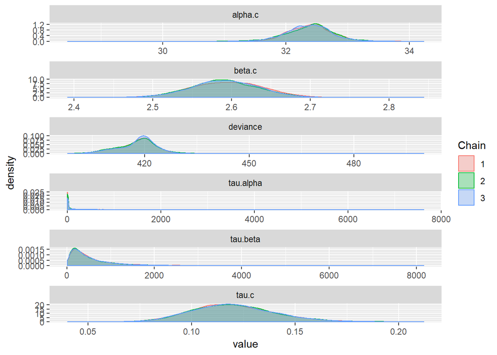

```r
results=ggs(jags_model.mcmc)
ggs_density(results)
```

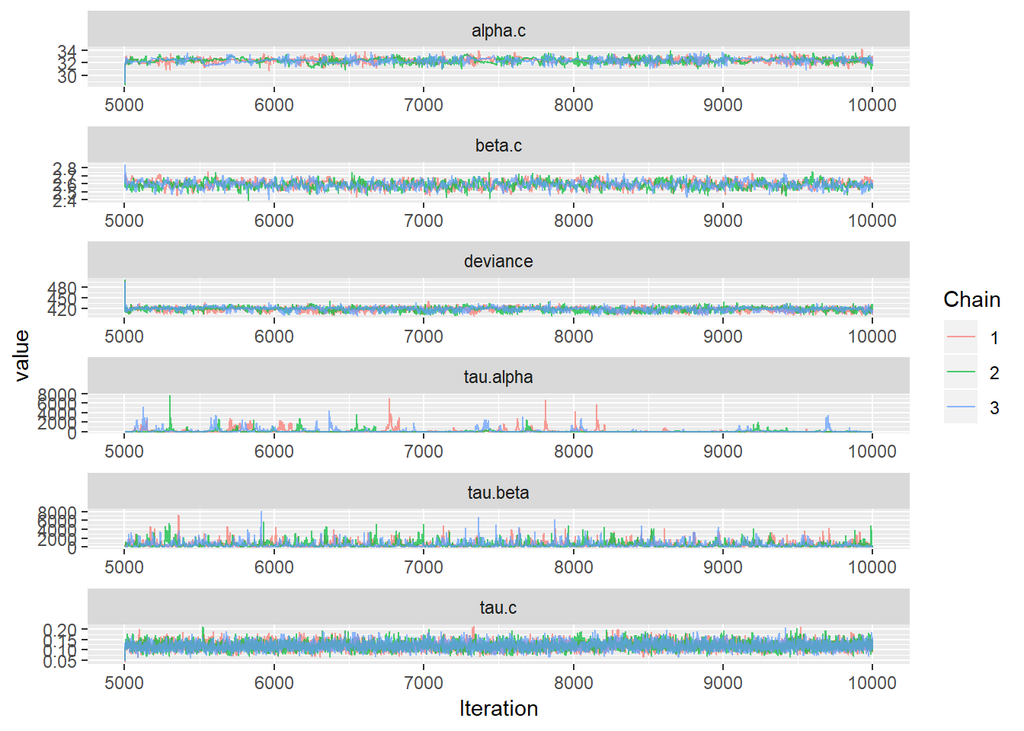

```r
ggs_traceplot(results)
```

The traceplots show that the parameters converge to the theoretical distributions.

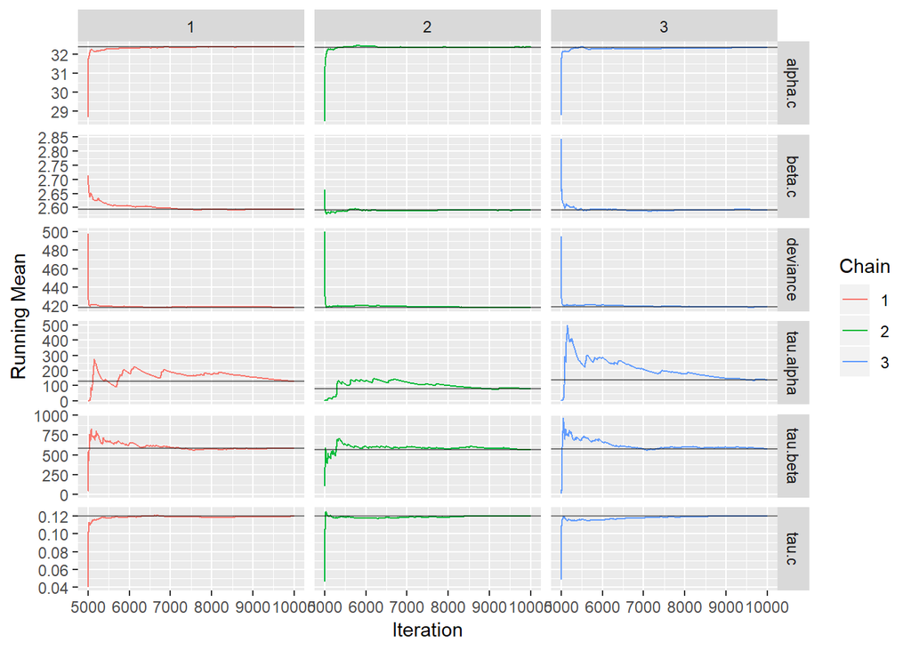

```r
ggs_running(results)
```

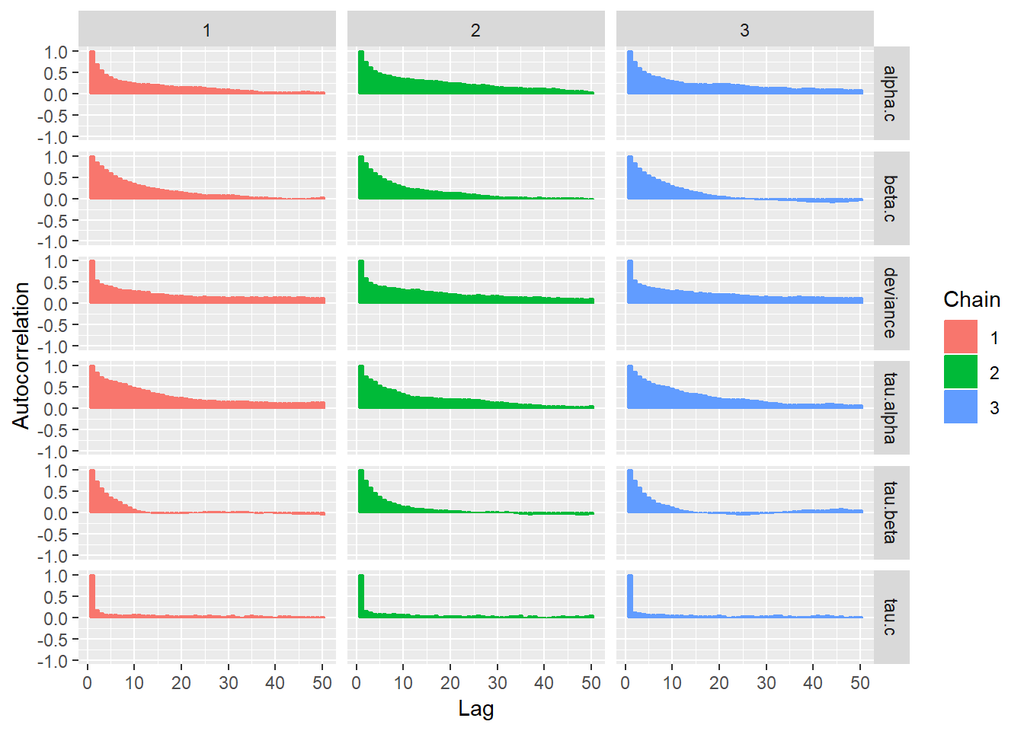

```r
ggs_autocorrelation(results)
```

# Diagnostics

-Gelman-Rubin-Brooks:

```r
gelman.diag(jags_model.mcmc)
```

```
## Potential scale reduction factors:
##
##           Point est. Upper C.I.
## alpha.c         1.00       1.00
## beta.c          1.00       1.01
## deviance        1.00       1.00
## tau.alpha       1.03       1.05
## tau.beta        1.00       1.00
## tau.c           1.00       1.00
##
## Multivariate psrf
##
## 1.01
```

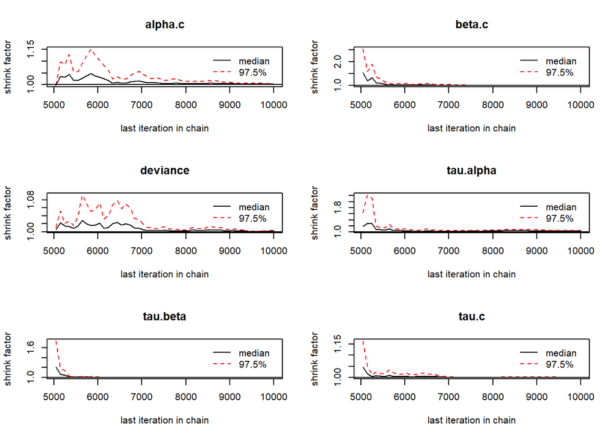

```r
gelman.plot(jags_model.mcmc)
```

It’s possible to see that for all the parameters there’s a convergence with the increasing of the iterations.

-Geweke-Brooks:

```r
geweke.diag(jags_model.mcmc)
```

```
## [[1]]
##
## Fraction in 1st window = 0.1
## Fraction in 2nd window = 0.5
##
##   alpha.c    beta.c  deviance tau.alpha  tau.beta     tau.c
##   -1.3356    1.3772    2.2907    0.4119    0.8630   -1.8265
##
##
## [[2]]
##
## Fraction in 1st window = 0.1
## Fraction in 2nd window = 0.5
##
##   alpha.c    beta.c  deviance tau.alpha  tau.beta     tau.c
##   0.03606  -0.95803   2.81350   1.03028   0.70402  -1.87876
##
##
## [[3]]
##
## Fraction in 1st window = 0.1
## Fraction in 2nd window = 0.5
##
##   alpha.c    beta.c  deviance tau.alpha  tau.beta     tau.c
## -0.138597  0.003484  4.857557  1.915759  1.674512 -4.471969
```

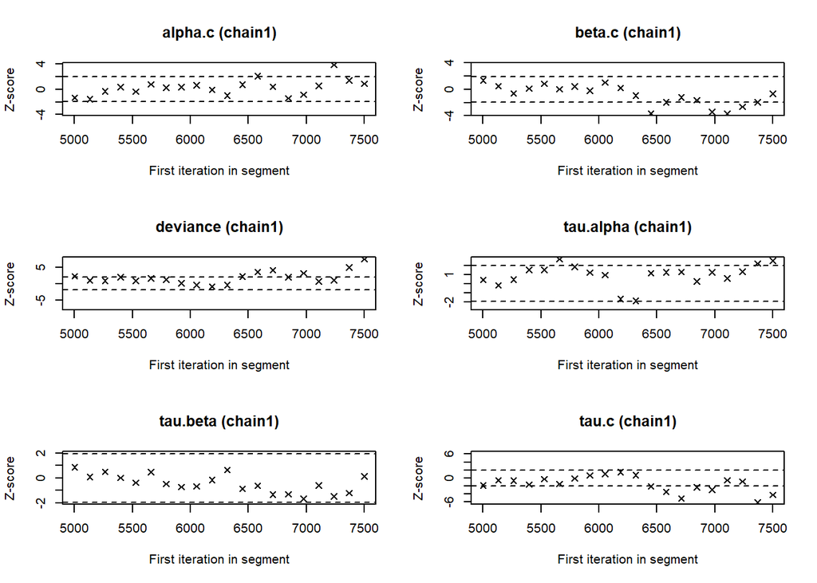

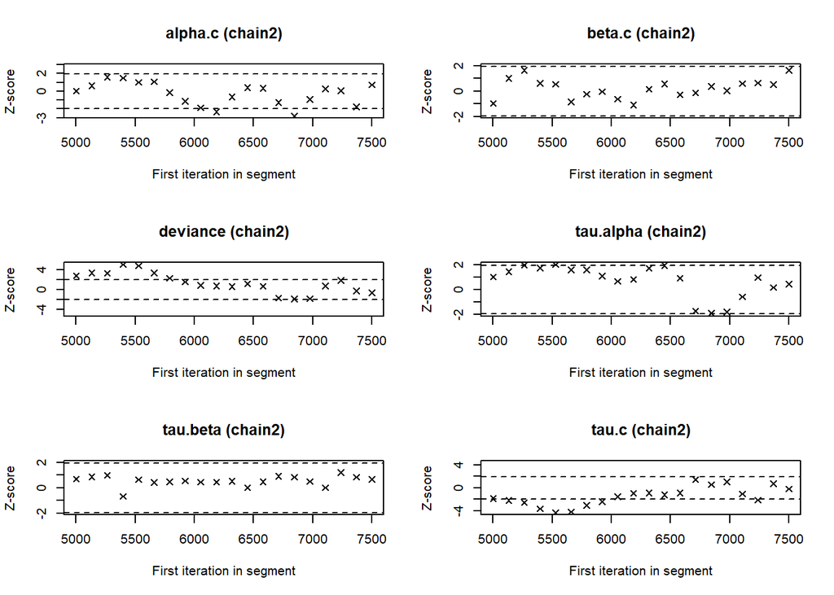

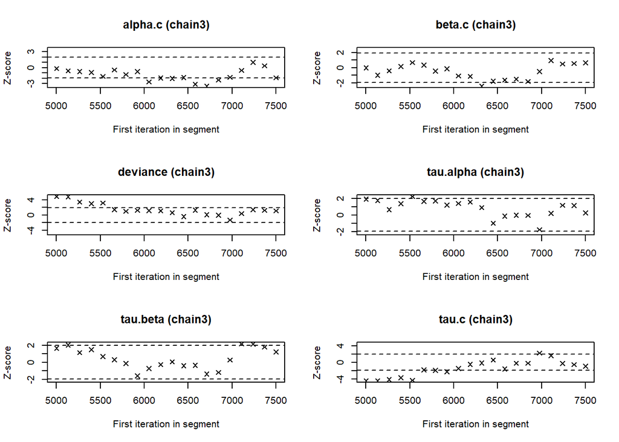

```r
geweke.plot(jags_model.mcmc)
```

-Raftery and Lewis’s diagnostic:

```r
raftery.diag(jags_model.mcmc)
```

```
## [[1]]
##
## Quantile (q) = 0.025
## Accuracy (r) = +/- 0.005
## Probability (s) = 0.95
##
##            Burn-in  Total Lower bound  Dependence
##            (M)      (N)   (Nmin)       factor (I)
##  alpha.c   7        7875  3746         2.10
##  beta.c    21       23049 3746         6.15
##  deviance  6        7866  3746         2.10
##  tau.alpha 6        6685  3746         1.78
##  tau.beta  8        10680 3746         2.85
##  tau.c     2        3900  3746         1.04
##
##
## [[2]]
##
## Quantile (q) = 0.025
## Accuracy (r) = +/- 0.005
## Probability (s) = 0.95
##
##            Burn-in  Total Lower bound  Dependence
##            (M)      (N)   (Nmin)       factor (I)
##  alpha.c   33       33825 3746         9.03
##  beta.c    14       14510 3746         3.87
##  deviance  6        9130  3746         2.44
##  tau.alpha 8        8534  3746         2.28
##  tau.beta  15       17178 3746         4.59
##  tau.c     2        3837  3746         1.02
##
##
## [[3]]
##
## Quantile (q) = 0.025
## Accuracy (r) = +/- 0.005
## Probability (s) = 0.95
##
##            Burn-in  Total Lower bound  Dependence
##            (M)      (N)   (Nmin)       factor (I)
##  alpha.c   28       33620 3746         8.970
##  beta.c    14       16314 3746         4.360
##  deviance  3        4338  3746         1.160
##  tau.alpha 10       12060 3746         3.220
##  tau.beta  10       10546 3746         2.820
##  tau.c     2        3594  3746         0.959
```

-Heidelberger and Welch’s convergence diagnostic:

```r
heidel.diag(jags_model.mcmc)
```

```
## [[1]]
##
##           Stationarity start     p-value
##           test         iteration
## alpha.c   passed        1        0.268995
## beta.c    passed        1        0.149862
## deviance  failed       NA        0.000512
## tau.alpha failed       NA        0.007050
## tau.beta  passed        1        0.527113
## tau.c     failed       NA        0.001101
##
##           Halfwidth Mean   Halfwidth
##           test
## alpha.c   passed     32.39  0.03785
## beta.c    passed      2.59  0.00497
## deviance  <NA>          NA       NA
## tau.alpha <NA>          NA       NA
## tau.beta  passed    582.73 45.07526
## tau.c     <NA>          NA       NA
##
## [[2]]
##
##           Stationarity start     p-value
##           test         iteration
## alpha.c   passed          1      0.6076
## beta.c    passed          1      0.8832
## deviance  passed        501      0.0567
## tau.alpha passed       1001      0.1216
## tau.beta  passed          1      0.3107
## tau.c     passed       1001      0.3019
##
##           Halfwidth Mean    Halfwidth
##           test
## alpha.c   passed     32.384  0.05401
## beta.c    passed      2.590  0.00475
## deviance  passed    417.547  0.86414
## tau.alpha failed     63.350 36.71902
## tau.beta  passed    567.499 50.34709
## tau.c     passed      0.121  0.00120
##
## [[3]]
##
##           Stationarity start     p-value
##           test         iteration
## alpha.c   passed       2001      0.268
## beta.c    passed          1      0.574
## deviance  passed       1001      0.467
## tau.alpha passed       1001      0.341
## tau.beta  passed          1      0.155
## tau.c     passed       1001      0.632
##
##           Halfwidth Mean    Halfwidth
##           test
## alpha.c   passed     32.420  0.03941
## beta.c    passed      2.592  0.00453
## deviance  passed    417.405  0.66930
## tau.alpha failed    101.919 43.50419
## tau.beta  passed    572.173 48.09012
## tau.c     passed      0.121  0.00100
```

# Comparative analysis with frequentist inference

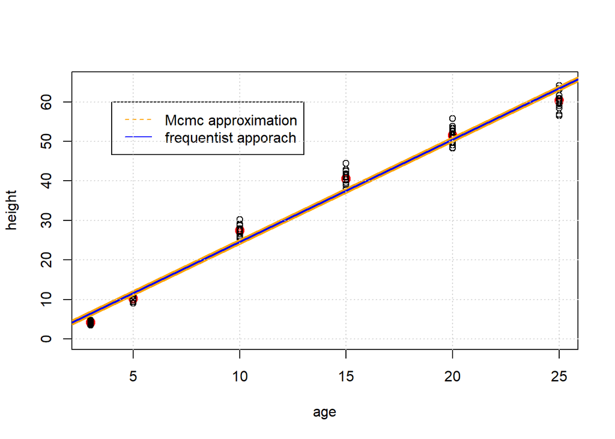

```r
plot(x,colMeans(Y), lwd=4, xlab = "age", ylab = "height",
     col="red", ylim=c(0,65))
points(rep(loblolly.data$x[1], N), Y[,1])
points(rep(loblolly.data$x[2], N), Y[,2])
points(rep(loblolly.data$x[3], N), Y[,3])
points(rep(loblolly.data$x[4], N), Y[,4])
points(rep(loblolly.data$x[5], N), Y[,5])
points(rep(loblolly.data$x[6], N), Y[,6])
abline(jags_model$BUGSoutput$mean$alpha.c-jags_model$BUGSoutput$mean$beta.c*x_bar,
       jags_model$BUGSoutput$mean$beta.c, col="orange", lwd=6)
abline(mean_alpha_freq, mean_beta_freq, col="blue", lwd=2)
legend(4, 60, legend=c("Mcmc approximation", "frequentist apporach"),
       col=c("orange", "blue"), lty=8:2, cex=1)
grid()
```

The plot shows how frequentist approach and bayesian approach lead to pretty similar results. It’s possibile to see this also by comparing the two summaries of the models.

# Model2

In this second model we want try to change some prior parameters and see what happen at our model. Our prior sigma.alpha and sigma.beta are distributed as uniform.

```r
model2 <- function()  {
  for (i in 1:N) {
    for (j in 1:T) {

      mu[i,j] <- alpha[i] + beta[i]*(x[j]-x.bar);
      Y[i,j]   ~ dnorm(mu[i,j],tau.c)

    }

    alpha[i] ~ dnorm(alpha.c,tau.alpha);
    beta[i]  ~ dnorm(beta.c,tau.beta); }
  alpha.c   ~ dnorm(0,1.0E-6);
  beta.c    ~ dnorm(0,1.0E-6);
  tau.c     <- 1.0 / (sigma*sigma);
  sigma  ~ dunif(0,100)
  tau.alpha <- 1.0 / (sigma.alpha*sigma.alpha);
  sigma.alpha ~ dunif(0,100)
  tau.beta <- 1/(sigma.beta*sigma.beta)
  sigma.beta ~ dunif(0,100)
  x.bar    <- mean(x[]);
  alpha0 <- alpha.c - beta.c * x.bar
}
```

```r
loblolly.params2 <- c("alpha.c", "beta.c", "sigma", "sigma.alpha", "sigma.beta")
```

Define the starting values for JAGS:

```r
loblolly.inits2 <- function(){
  list(alpha=c(-1.31,-1.31,-1.31,-1.31,-1.31,-1.31,-1.31,-1.31,-1.31,-1.31,-1.31,-1.31,-1.31,-1.31),
       beta = c(2.6,2.6,2.6,2.6,2.6,2.6,2.6,2.6,2.6,2.6,2.6,2.6,2.6,2.6),
       alpha.c = 4.24, beta.c = 10,
       sigma = 1, sigma.alpha = 1, sigma.beta = 1) }
```

Jags model:

```r
jags_model2 <- jags(data=loblolly.data.list, inits=loblolly.inits2, loblolly.params2, n.chains=3, n.iter=10000, n.burnin=5000, n.thin=1, model.file=model2)
```

# Evaluation of the output

First, let’s compare the ouputs of the intercept and the splope with the frequentist approach and the first model:

```r
cat('Intercept mean with bayesian approach: ', round(jags_model2$BUGSoutput$mean$alpha.c-jags_model2$BUGSoutput$mean$beta.c*x_bar,2))
```

```
## Intercept mean with bayesian approach:  -1.26
```

```r
cat('Slope mean with bayesian approach: ', round(jags_model2$BUGSoutput$mean$beta.c,2))
```

```
## Slope mean with bayesian approach:  2.59
```

Again, we got similar results to the frequentist ones.

```r
jags_model2.mcmc <- as.mcmc(jags_model2)
summary(jags_model2)
```

```
##                    Length Class  Mode
## model               8     jags   list
## BUGSoutput         24     bugs   list
## parameters.to.save  6     -none- character
## model.file          1     -none- character
## n.iter              1     -none- numeric
## DIC                 1     -none- logical
```

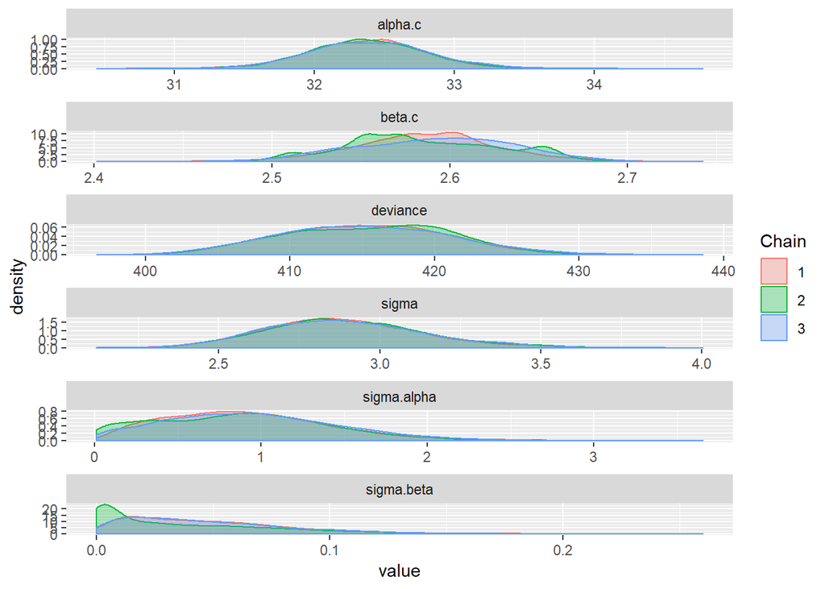

```r
results2=ggs(jags_model2.mcmc)
ggs_density(results2)
```

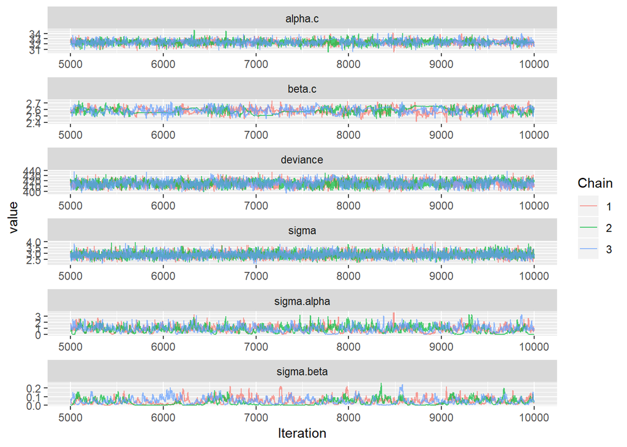

```r
ggs_traceplot(results2)
```

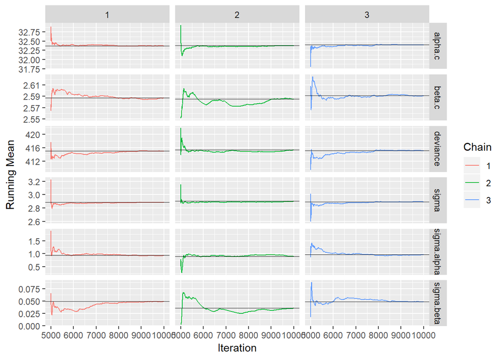

```r
ggs_running(results2)
```

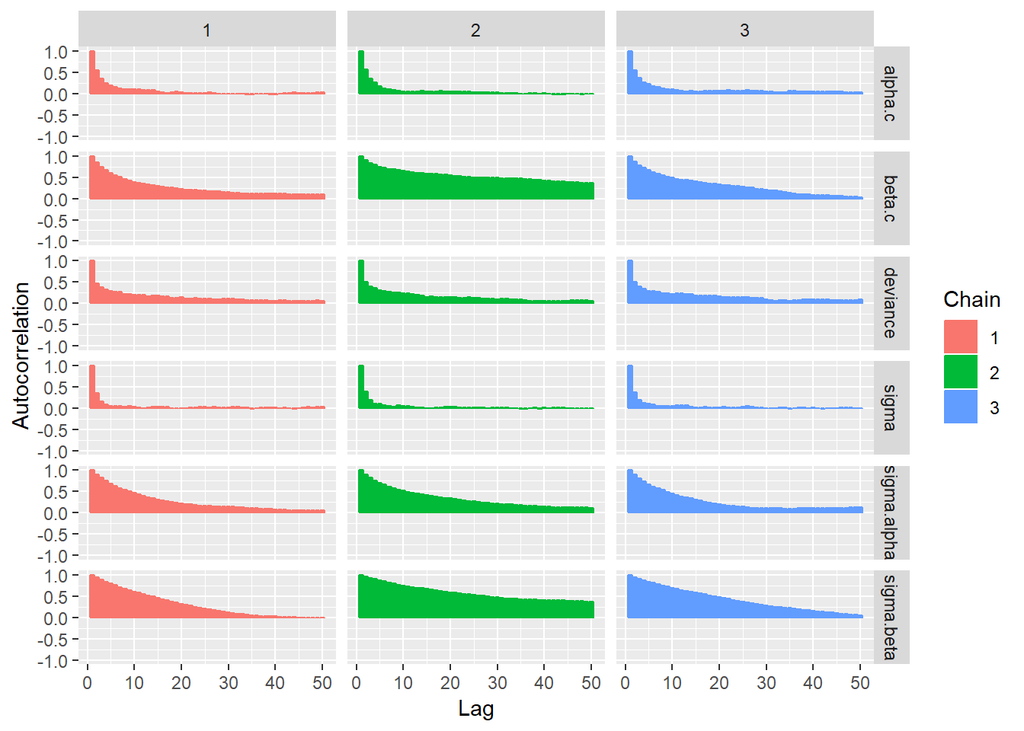

```r
ggs_autocorrelation(results2)
```

# Diagnostics

-Gelman-Rubin-Brooks:

```r
gelman.diag(jags_model2.mcmc)
```

```
## Potential scale reduction factors:
##
##             Point est. Upper C.I.
## alpha.c           1.00       1.00
## beta.c            1.00       1.01
## deviance          1.00       1.00
## sigma             1.00       1.00
## sigma.alpha       1.00       1.01
## sigma.beta        1.03       1.10
##
## Multivariate psrf
##
## 1.03
```

We got good results for all parameters.

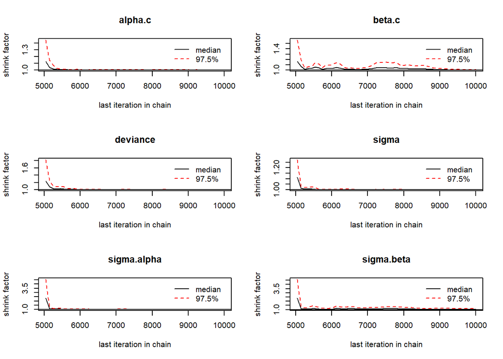

```r
gelman.plot(jags_model2.mcmc)
```

-Geweke-Brooks:

```r
geweke.diag(jags_model2.mcmc)
```

```
## [[1]]
##
## Fraction in 1st window = 0.1
## Fraction in 2nd window = 0.5
##
##     alpha.c      beta.c    deviance       sigma sigma.alpha  sigma.beta
##      1.0712      3.2908     -2.2994     -1.9281      0.7261     -2.1931
##
##
## [[2]]
##
## Fraction in 1st window = 0.1
## Fraction in 2nd window = 0.5
##
##     alpha.c      beta.c    deviance       sigma sigma.alpha  sigma.beta
##     -1.1842     -0.2345     -0.4642     -1.0395      0.3707      0.9788
##
##
## [[3]]
##
## Fraction in 1st window = 0.1
## Fraction in 2nd window = 0.5
##
##     alpha.c      beta.c    deviance       sigma sigma.alpha  sigma.beta
##     -0.9340     -0.5030     -4.0942     -2.9233      2.8365     -0.0693
```

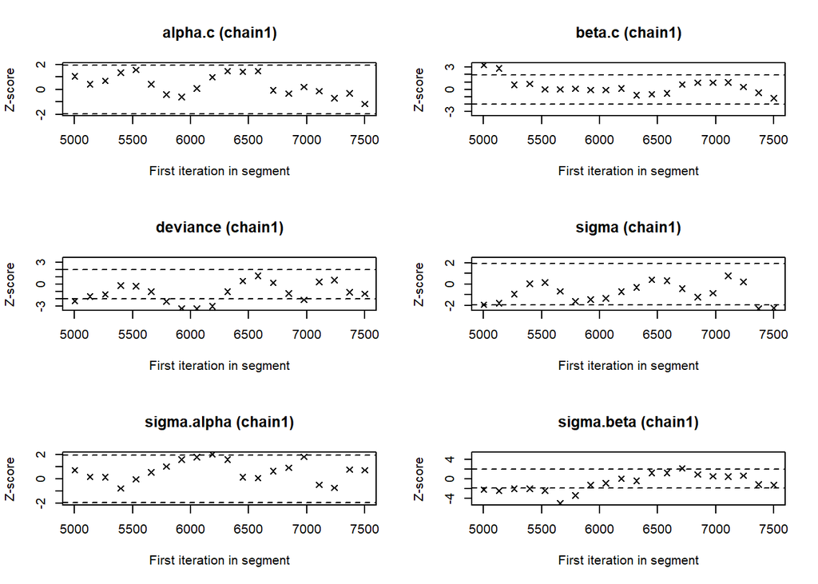

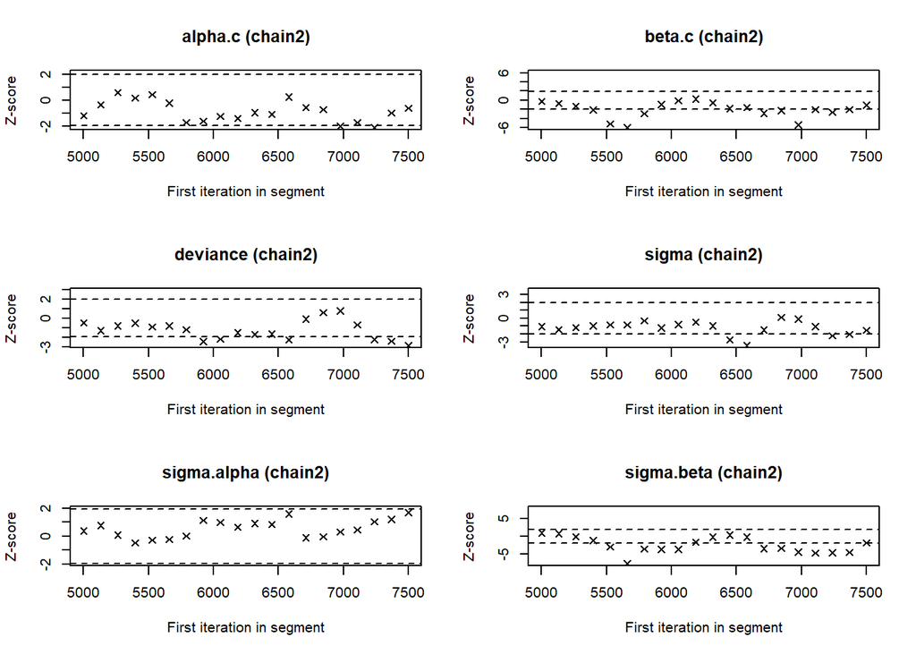

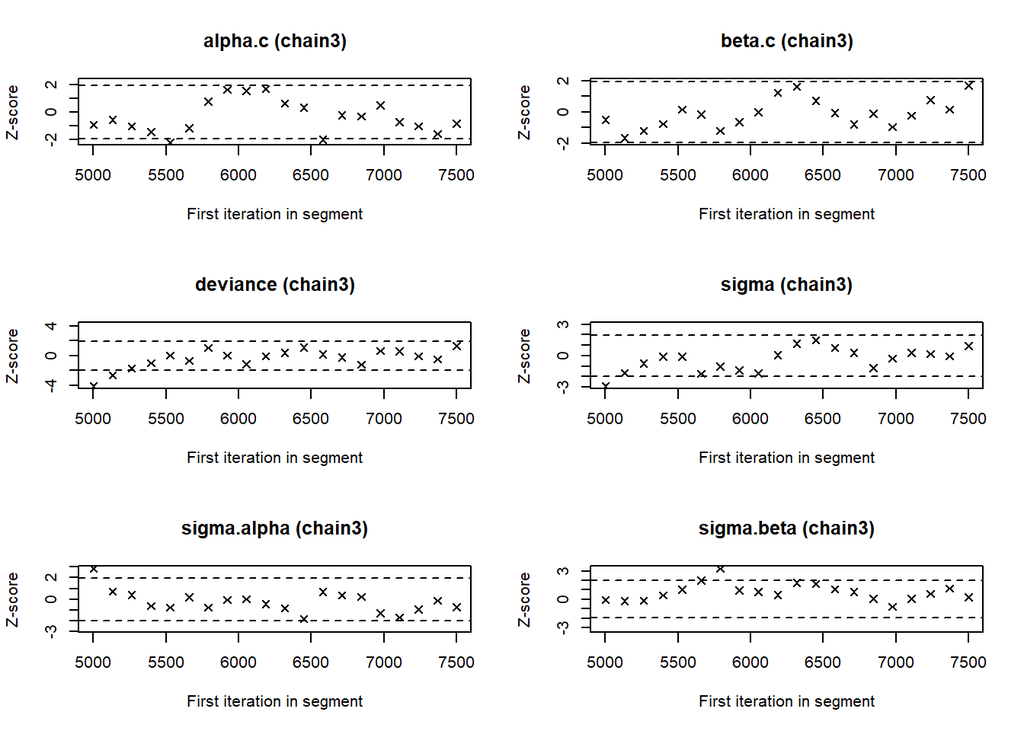

```r
geweke.plot(jags_model2.mcmc)
```

-Raftery and Lewis’s diagnostic:

```r
raftery.diag(jags_model2.mcmc)
```

```
## [[1]]
##
## Quantile (q) = 0.025
## Accuracy (r) = +/- 0.005
## Probability (s) = 0.95
##
##              Burn-in  Total Lower bound  Dependence
##              (M)      (N)   (Nmin)       factor (I)
##  alpha.c     5        5771  3746          1.54
##  beta.c      22       25324 3746          6.76
##  deviance    3        4484  3746          1.20
##  sigma       5        5771  3746          1.54
##  sigma.alpha 52       53096 3746         14.20
##  sigma.beta  72       81676 3746         21.80
##
##
## [[2]]
##
## Quantile (q) = 0.025
## Accuracy (r) = +/- 0.005
## Probability (s) = 0.95
##
##              Burn-in  Total  Lower bound  Dependence
##              (M)      (N)    (Nmin)       factor (I)
##  alpha.c     8        8436   3746          2.25
##  beta.c      24       27348  3746          7.30
##  deviance    4        4955   3746          1.32
##  sigma       5        5391   3746          1.44
##  sigma.alpha 100      111936 3746         29.90
##  sigma.beta  120      146100 3746         39.00
##
##
## [[3]]
##
## Quantile (q) = 0.025
## Accuracy (r) = +/- 0.005
## Probability (s) = 0.95
##
##              Burn-in  Total Lower bound  Dependence
##              (M)      (N)   (Nmin)       factor (I)
##  alpha.c     4        5124  3746          1.37
##  beta.c      14       18140 3746          4.84
##  deviance    3        4062  3746          1.08
##  sigma       4        4955  3746          1.32
##  sigma.alpha 76       79420 3746         21.20
##  sigma.beta  76       85860 3746         22.90
```

-Heidelberger and Welch’s convergence diagnostic:

```r
heidel.diag(jags_model2.mcmc)
```

```
## [[1]]
##
##             Stationarity start     p-value
##             test         iteration
## alpha.c     passed         1       0.336
## beta.c      passed         1       0.354
## deviance    passed         1       0.163
## sigma       passed         1       0.178
## sigma.alpha passed         1       0.364
## sigma.beta  passed       501       0.127
##
##             Halfwidth Mean     Halfwidth
##             test
## alpha.c     passed     32.3696 0.0283
## beta.c      passed      2.5869 0.0056
## deviance    passed    415.0366 0.5809
## sigma       passed      2.8836 0.0112
## sigma.alpha passed      0.9291 0.0691
## sigma.beta  failed      0.0512 0.0066
##
## [[2]]
##
##             Stationarity start     p-value
##             test         iteration
## alpha.c     passed        1        0.20530
## beta.c      failed       NA        0.00812
## deviance    passed        1        0.11094
## sigma       failed       NA        0.02716
## sigma.alpha passed        1        0.11270
## sigma.beta  failed       NA        0.01327
##
##             Halfwidth Mean    Halfwidth
##             test
## alpha.c     passed     32.374 0.0251
## beta.c      <NA>           NA     NA
## deviance    passed    415.367 0.6606
## sigma       <NA>           NA     NA
## sigma.alpha passed      0.896 0.0871
## sigma.beta  <NA>           NA     NA
##
## [[3]]
##
##             Stationarity start     p-value
##             test         iteration
## alpha.c     passed       1         0.7001
## beta.c      passed       1         0.9323
## deviance    passed       1         0.3525
## sigma       passed       1         0.0968
## sigma.alpha passed       1         0.5238
## sigma.beta  passed       1         0.4281
##
##             Halfwidth Mean     Halfwidth
##             test
## alpha.c     passed     32.3950 0.03621
## beta.c      passed      2.5910 0.00724
## deviance    passed    415.1626 0.65218
## sigma       passed      2.8925 0.01396
## sigma.alpha passed      0.9585 0.07173
## sigma.beta  failed      0.0484 0.00737
```

# Comparative analysis with frequentist inference

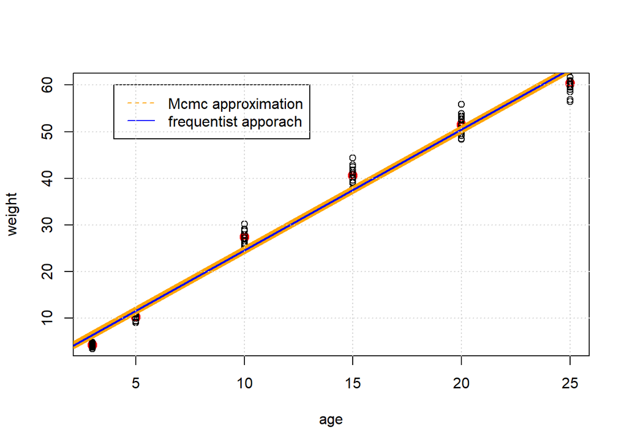

```r
plot(x,colMeans(Y), lwd=4, xlab = "age", ylab = "weight",
     col="red")
points(rep(x[1],N), Y[,1])
points(rep(x[2],N), Y[,2])
points(rep(x[3],N), Y[,3])
points(rep(x[4],N), Y[,4])
points(rep(x[5],N), Y[,5])
points(rep(x[6],N), Y[,6])
abline(jags_model2$BUGSoutput$mean$alpha.c-jags_model2$BUGSoutput$mean$beta.c*x_bar,
       jags_model2$BUGSoutput$mean$beta.c, col="orange", lwd=8)
abline(mean_alpha_freq, mean_beta_freq, col="blue", lwd=2)
legend(4, 60, legend=c("Mcmc approximation", "frequentist apporach"),
       col=c("orange", "blue"), lty=8:2, cex=1)
grid()
```

As happened for first model, we got similar results for both methods.

# Model comparison through DIC

Let’s compare two model with the Deviance Information Criterion: this analyzes the models in terms of deviance. and is given by $DIC = \overline{D} + p_D$ or $DIC = \hat{D} + 2 * p_D$ . $p_D$ : this is ‘the effective number of parameters’, and is given by $pD = \overline{D}-\hat{D}$. Thus $p_D$ is the posterior mean of the deviance minus the deviance of the posterior means. $\hat{D}$ : this is a point estimate of the deviance ($2log(L(\bar{\theta}))$) obtained by substituting in the posterior means theta.ba r of thet a: thus $\hat{D}= -2 * log(p(y|\overline{\theta}))$. $\overline{D}$ : this is the posterior mean of the deviance, which is exactly the same as if the node ‘deviance’ had been monitored. This deviance is defined as $-2 * log(L)$: ‘likelihood’ is defined as $p(y|\theta)$, where y comprises all stochastic nodes given values (i.e. data), and thet a comprises the stochastic parent s of y - ‘stochastic parents’ are the stochastic nodes upon which the distribution of y depends, when collapsing over all logical relationships.

The model with the smallest DIC is estimated to be the model that would best predict a replicate dataset of the same structure as that currently observed.

```r
cat('DIC for 1st model: ', jags_model$BUGSoutput$DIC)
```

```
## DIC for 1st model:  433.8871
```

```r
cat('DIC fro 2nd model: ', jags_model2$BUGSoutput$DIC)
```

```
## DIC fro 2nd model:  432.2262
```

Due to slower DIC’s value for the second model it’s possible say that this one works better than the first.